# Lab 2: Exploratory Data Analysis (Python, Pandas & matplotlib)

In this lab 2, we are going to learn how to explore data using Python. Namely, we will work with Pandas and matplotlib, for data filtering and grouping, and visualization respectively. Provided VM is recommeded for this lab.

## Setup

#### This Notebook

Download this notebook so you can edit it. (If you are viewing it via nbviewer.ipython.org, then use the link in the upper right corner.) To edit this notebook, in your VM terminal, type "ipython notebook" and in your prompted brower, click the notebook file to open and edit it.

#### Data

For question 1 and 2, use the sampled data, download the file [wc_day6_1_sample.csv](https://ufl.instructure.com/courses/390786/files/folder/labs/Lab2%263). For question3, use the following file [wc_day91_1_log.csv](https://ufl.instructure.com/files/47705707/download?download_frd=1). Put them both in your VM (To enable the 'Drag'n Drop' for ease of transfering files to/from VM, go to Device -> Drag 'n Drop -> Bidirectional)

## Pandas

The two main data structures used by pandas are

- Series: one-dimensional collections of any data type.
- DataFrames: two-dimensional data structures similar to a database table.

At first, we need to import the libraries we need. In the code cell below, we will import two libraries, pandas for data processing and PyLab for plotting.

To run the code in the cell below, select the cell, then press 'ctrl + enter', or hit the 'play' button above.

```python
import matplotlib
from matplotlib import pylab
import pandas as pd
```

## The Basics

To create our first DataFrame using pandas, run:

```python
df = pd.DataFrame( { 'a' : [1, 2, 3, 4], 'b': [ 'w', 'x', 'y', 'z'] })
```

This is going to create a table with two columns and four rows, we can inspect the DataFrame by typing the name on the object:

```python
df
```

|  | a | b |
| --- | --- | --- |
| 0 | 1 | w |
| 1 | 2 | x |
| 2 | 3 | y |
| 3 | 4 | z |

For more detailed information about the schema of a DataFrame we can use the info function:

```python
df.info()
```

```
<class 'pandas.core.frame.DataFrame'>
RangeIndex: 4 entries, 0 to 3
Data columns (total 2 columns):
a    4 non-null int64
b    4 non-null object
dtypes: int64(1), object(1)
memory usage: 136.0+ bytes
```

To check the first few rows we can use head and the last few rows tail functions

```python
df.head(2)
```

|  | a | b |
| --- | --- | --- |
| 0 | 1 | w |
| 1 | 2 | x |

df.tail(2)

To access any range of rows in the DataFrame we can use array-like indexes, for example, the following will retrieve rows 1 and 2 from our DataFrame:

```python
df[1:3]
```

|  | a | b |
| --- | --- | --- |
| 1 | 2 | x |
| 2 | 3 | y |

For the following exercises we will use the dataset mentioned in setup.

After you download this CSV file, we can import it into a DataFrame, assuming the file is in the path /home/datascience/

```python
log_df = pd.read_csv("./wc_day6_1_sample.csv",
                     names=['ClientID', 'Date', 'Time', 'URL', 'ResponseCode', 'Size'],
                     na_values=['-'])
log_df.loc[:,('DateTime')] = pd.to_datetime(log_df.apply(lambda row: row['Date'] + ' ' + row['Time'], axis=1))
log_df['hour'] = log_df.DateTime.dt.hour
log_df['URL_type'] = log_df['URL'].str.split(".", n = -1, expand = False).str.get(-1)
gif = log_df[log_df['URL_type'] == 'gif']
#log_df.plot(kind = 'scatter', x = day_df2['hour'], y = day_df2['URL_type'].nunique())
```

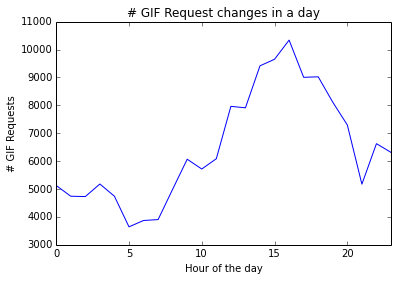

```python
#gif.groupby('hour').size().plot(kind='bar', legend='false')
%matplotlib inline
ax = gif.groupby('hour').size().plot()
ax.set_ylabel("# GIF Requests")
ax.set_xlabel("Hour of the day")
ax.set_title("# GIF Request changes in a day")
```

Using read_csv function, we created a new DataFrame with column names passed as a list in the names parameter and null or non existing values represented with "-" in the na_values parameter.

## More complex operations

#### Row filtering

To create row filters, we use lists of Boolean values that evaluate a condition:

```python
is_may1st = log_df['Date'] == '01/May/1998'
```

This returns a list of True/False values for each row in **log_df** that evaluate the given condition. To filter using this list:

```python
may1_df = log_df[is_may1st]
may1_df
```

|  | ClientID | Date | Time | URL | ResponseCode | Size | DateTime | hour | URL_type |
| --- | --- | --- | --- | --- | --- | --- | --- | --- | --- |
| 1 | 10871 | 01/May/1998 | 12:10:53 | /images/ligne.gif | 200.0 | 169.0 | 1998-05-01 12:10:53 | 12 | gif |
| 2 | 11012 | 01/May/1998 | 12:17:30 | /english/individuals/player111503.htm | 200.0 | 7027.0 | 1998-05-01 12:17:30 | 12 | htm |
| 3 | 11435 | 01/May/1998 | 13:15:13 | /french/frntpage.htm | 304.0 | 0.0 | 1998-05-01 13:15:13 | 13 | htm |
| 4 | 12128 | 01/May/1998 | 13:30:21 | /english/images/nav_sitemap_off.gif | 304.0 | NaN | 1998-05-01 13:30:21 | 13 | gif |
| 5 | 13649 | 01/May/1998 | 14:55:01 | /images/hm_anime_e.gif | 200.0 | 15609.0 | 1998-05-01 14:55:01 | 14 | gif |
| 6 | 15006 | 01/May/1998 | 16:14:32 | /english/images/comp_bu_group_off.gif | 200.0 | 1557.0 | 1998-05-01 16:14:32 | 16 | gif |
| 7 | 16366 | 01/May/1998 | 17:14:13 | /images/arw_lk.gif | 200.0 | 669.0 | 1998-05-01 17:14:13 | 17 | gif |
| 8 | 16877 | 01/May/1998 | 17:46:37 | /images/32p49807.jpg | 200.0 | 13856.0 | 1998-05-01 17:46:37 | 17 | jpg |
| 9 | 17165 | 01/May/1998 | 17:58:46 | /images/home_fr_button.gif | 200.0 | 2140.0 | 1998-05-01 17:58:46 | 17 | gif |
| 10 | 17251 | 01/May/1998 | 18:06:07 | /images/s102438.gif | 200.0 | 297.0 | 1998-05-01 18:06:07 | 18 | gif |
| 11 | 1734 | 01/May/1998 | 12:57:32 | /english/venues/cities/images/paris/21hundred.gif | 200.0 | 318.0 | 1998-05-01 12:57:32 | 12 | gif |
| 12 | 17501 | 01/May/1998 | 18:17:26 | /english/competition/flashed_stage1.htm | 200.0 | 3541.0 | 1998-05-01 18:17:26 | 18 | htm |
| 13 | 18632 | 01/May/1998 | 19:27:09 | /images/backnews.gif | 200.0 | 4573.0 | 1998-05-01 19:27:09 | 19 | gif |
| 14 | 18902 | 01/May/1998 | 19:45:47 | /images/dot.gif | 200.0 | 43.0 | 1998-05-01 19:45:47 | 19 | gif |
| 15 | 20505 | 01/May/1998 | 21:36:22 | /english/images/nav_store_off.gif | 304.0 | 0.0 | 1998-05-01 21:36:22 | 21 | gif |
| 16 | 3168 | 01/May/1998 | 04:45:35 | /english/images/news_btn_press_off.gif | 200.0 | 1740.0 | 1998-05-01 04:45:35 | 4 | gif |
| 17 | 3250 | 01/May/1998 | 01:20:20 | /images/s140875.gif | 200.0 | 184.0 | 1998-05-01 01:20:20 | 1 | gif |
| 18 | 4293 | 01/May/1998 | 03:22:58 | /english/playing/mascot/images/footix.test.gif | 200.0 | 20385.0 | 1998-05-01 03:22:58 | 3 | gif |
| 19 | 4518 | 01/May/1998 | 03:12:52 | /english/images/nav_field_off.gif | 304.0 | 0.0 | 1998-05-01 03:12:52 | 3 | gif |
| 20 | 5518 | 01/May/1998 | 04:26:52 | /english/nav_inet.html | 200.0 | 2672.0 | 1998-05-01 04:26:52 | 4 | html |
| 21 | 5842 | 01/May/1998 | 04:58:25 | /english/playing/images/play_hm_trivia.gif | 200.0 | 796.0 | 1998-05-01 04:58:25 | 4 | gif |
| 22 | 5959 | 01/May/1998 | 05:32:07 | /images/space.gif | 200.0 | 42.0 | 1998-05-01 05:32:07 | 5 | gif |
| 23 | 6904 | 01/May/1998 | 13:09:01 | /english/history/body.html | 304.0 | NaN | 1998-05-01 13:09:01 | 13 | html |
| 24 | 7706 | 01/May/1998 | 08:01:19 | /english/ProScroll.class | 200.0 | 6507.0 | 1998-05-01 08:01:19 | 8 | class |
| 25 | 8103 | 01/May/1998 | 08:36:53 | /english/images/news_btn_kits_off.gif | 200.0 | 933.0 | 1998-05-01 08:36:53 | 8 | gif |
| 26 | 8278 | 01/May/1998 | 14:38:57 | /french/playing/images/play_mascot_header.gif | 304.0 | 0.0 | 1998-05-01 14:38:57 | 14 | gif |
| 27 | 8846 | 01/May/1998 | 17:06:36 | /images/hm_brdl.gif | 304.0 | 0.0 | 1998-05-01 17:06:36 | 17 | gif |
| 28 | 9788 | 01/May/1998 | 10:43:09 | /images/s102378.gif | 200.0 | 118.0 | 1998-05-01 10:43:09 | 10 | gif |
| 29 | 10686 | 01/May/1998 | 12:04:38 | /images/info.gif | 304.0 | NaN | 1998-05-01 12:04:38 | 12 | gif |
| 30 | 11012 | 01/May/1998 | 12:17:23 | /images/arw_lk.gif | 200.0 | 669.0 | 1998-05-01 12:17:23 | 12 | gif |
| ... | ... | ... | ... | ... | ... | ... | ... | ... | ... |
| 199966 | 10845 | 01/May/1998 | 12:06:01 | /images/space.gif | 200.0 | 42.0 | 1998-05-01 12:06:01 | 12 | gif |
| 199967 | 11147 | 01/May/1998 | 12:32:28 | /images/s102330.gif | 304.0 | 0.0 | 1998-05-01 12:32:28 | 12 | gif |
| 199968 | 11618 | 01/May/1998 | 13:06:41 | /images/102320.gif | 200.0 | 1750.0 | 1998-05-01 13:06:41 | 13 | gif |
| 199969 | 13282 | 01/May/1998 | 14:38:28 | /images/s102329.gif | 200.0 | 159.0 | 1998-05-01 14:38:28 | 14 | gif |
| 199970 | 14121 | 01/May/1998 | 15:19:21 | /images/space.gif | 200.0 | 42.0 | 1998-05-01 15:19:21 | 15 | gif |
| 199971 | 16012 | 01/May/1998 | 17:02:46 | /english/playing/images/trivia/submit.gif | 200.0 | 1808.0 | 1998-05-01 17:02:46 | 17 | gif |
| 199972 | 16596 | 01/May/1998 | 17:26:05 | /english/ProScroll.class | 200.0 | 6507.0 | 1998-05-01 17:26:05 | 17 | class |
| 199973 | 17660 | 01/May/1998 | 18:26:25 | /english/images/comp_bu_groupsn_on.gif | 200.0 | 963.0 | 1998-05-01 18:26:25 | 18 | gif |
| 199974 | 18543 | 01/May/1998 | 19:26:42 | /images/news_hm_arw.gif | 200.0 | 152.0 | 1998-05-01 19:26:42 | 19 | gif |
| 199975 | 19381 | 01/May/1998 | 20:16:42 | / | 200.0 | 8712.0 | 1998-05-01 20:16:42 | 20 | / |
| 199976 | 4512 | 01/May/1998 | 03:05:46 | /english/images/top_stories.gif | 200.0 | 1210.0 | 1998-05-01 03:05:46 | 3 | gif |
| 199977 | 4542 | 01/May/1998 | 17:56:42 | /images/s102373.gif | 304.0 | 0.0 | 1998-05-01 17:56:42 | 17 | gif |
| 199978 | 5029 | 01/May/1998 | 03:43:58 | /french/images/nav_hosts_off.gif | 200.0 | 1139.0 | 1998-05-01 03:43:58 | 3 | gif |
| 199980 | 5613 | 01/May/1998 | 04:41:50 | /english/member/images/banner.jpg | 200.0 | 13120.0 | 1998-05-01 04:41:50 | 4 | jpg |
| 199981 | 6414 | 01/May/1998 | 05:54:17 | /english/nav_inet.html | 200.0 | 2672.0 | 1998-05-01 05:54:17 | 5 | html |
| 199982 | 6555 | 01/May/1998 | 08:00:12 | /english/images/news_btn_press_off.gif | 200.0 | 1740.0 | 1998-05-01 08:00:12 | 8 | gif |
| 199983 | 72 | 01/May/1998 | 13:42:05 | /images/arw_lk.gif | 200.0 | 669.0 | 1998-05-01 13:42:05 | 13 | gif |
| 199984 | 78 | 01/May/1998 | 11:19:46 | /english/images/top_stories.gif | 200.0 | 1210.0 | 1998-05-01 11:19:46 | 11 | gif |
| 199986 | 8678 | 01/May/1998 | 09:15:22 | /images/hm_anime_f.gif | 200.0 | 15529.0 | 1998-05-01 09:15:22 | 9 | gif |
| 199987 | 8051 | 01/May/1998 | 16:35:07 | /french/images/nav_field_off.gif | 200.0 | 982.0 | 1998-05-01 16:35:07 | 16 | gif |
| 199988 | 10103 | 01/May/1998 | 16:12:29 | /images/s102386.gif | 200.0 | 279.0 | 1998-05-01 16:12:29 | 16 | gif |
| 199989 | 10156 | 01/May/1998 | 11:14:32 | /english/playing/images/play_hm_bg_opt1.jpg | 200.0 | 44502.0 | 1998-05-01 11:14:32 | 11 | jpg |
| 199990 | 10215 | 01/May/1998 | 16:32:01 | /images/home_eng_phrase.gif | 200.0 | 2861.0 | 1998-05-01 16:32:01 | 16 | gif |
| 199991 | 12459 | 01/May/1998 | 13:50:21 | /english/images/nav_home_off.gif | 200.0 | 828.0 | 1998-05-01 13:50:21 | 13 | gif |
| 199992 | 13015 | 01/May/1998 | 14:23:33 | /images/hm_nbg.jpg | 200.0 | 33665.0 | 1998-05-01 14:23:33 | 14 | jpg |
| 199995 | 14308 | 01/May/1998 | 15:31:30 | /english/images/news_btn_press_off.gif | 200.0 | 1740.0 | 1998-05-01 15:31:30 | 15 | gif |
| 199996 | 14401 | 01/May/1998 | 15:54:00 | /images/102338.gif | 200.0 | 1573.0 | 1998-05-01 15:54:00 | 15 | gif |
| 199997 | 8145 | 01/May/1998 | 08:41:37 | /english/news/player01.htm | 200.0 | 42591.0 | 1998-05-01 08:41:37 | 8 | htm |
| 199998 | 17799 | 01/May/1998 | 18:34:08 | /english/images/nav_team_off.gif | 200.0 | 776.0 | 1998-05-01 18:34:08 | 18 | gif |
| 199999 | 18194 | 01/May/1998 | 19:07:24 | /french/playing/images/trivia/02comme.gif | 200.0 | 944.0 | 1998-05-01 19:07:24 | 19 | gif |

183303 rows × 9 columns

This can be done more concisely:

```python
may1_df = log_df[log_df['Date'] == '01/May/1998']
```

#### Column filtering

For column filters, we use the name of the columns that we want to keep passes as a string array:

```python
url_codes = log_df[['URL', 'ResponseCode']]
```

#### Grouping

For grouping by a column, i.e. dividing all the rows into groups of the same value in that column, we use **groupby** which does not return a DataFrame but a **DataFrameGroupBy** object. The **DataFrameGroupBy** object is a dictionary-like object where keys are the distinct values in the grouping column, and values are DataFrames containnig th remaining columns

```python
grouped = log_df.groupby('ResponseCode')
```

```python
grouped.get_group(200).info()
```

```
<class 'pandas.core.frame.DataFrame'>
Int64Index: 173924 entries, 0 to 199999
Data columns (total 9 columns):
ClientID        173924 non-null int64
Date            173924 non-null object
Time            173924 non-null object
URL             173924 non-null object
ResponseCode    173924 non-null float64
Size            173924 non-null float64
DateTime        173924 non-null datetime64[ns]
hour            173924 non-null int64
URL_type        173924 non-null object
dtypes: datetime64[ns](1), float64(2), int64(2), object(4)
memory usage: 13.3+ MB
```

```python
# group by multiple columns
multi_grouped = log_df.groupby(['ResponseCode', 'Date'])
```

Similarly, we can apply operations to each group such as:

```python
multi_grouped.get_group((200, '30/Apr/1998')).info()
```

```
<class 'pandas.core.frame.DataFrame'>
Int64Index: 14577 entries, 0 to 199994
Data columns (total 9 columns):
ClientID        14577 non-null int64
Date            14577 non-null object
Time            14577 non-null object
URL             14577 non-null object
ResponseCode    14577 non-null float64
Size            14577 non-null float64
DateTime        14577 non-null datetime64[ns]
hour            14577 non-null int64
URL_type        14577 non-null object
dtypes: datetime64[ns](1), float64(2), int64(2), object(4)
memory usage: 1.1+ MB
```

```python
grouped.size()
# returns a panda Series(1-d array with the groupby value(s)as index, count of each group as data values.)
```

```
ResponseCode
200.0    173924
206.0       379
302.0        14
304.0     25457
400.0         3
404.0       215
500.0         5
dtype: int64
```

```python
grouped.sum(), grouped.mean(), grouped.median()
```

```
(                ClientID          Size     hour
 ResponseCode
 200.0         1747413714  1.468218e+09  2227190
 206.0            3943763  3.399102e+07     4791
 302.0             160809  3.334000e+03      152
 304.0          228519101  1.994370e+05   323252
 400.0              14153  4.080000e+02       58
 404.0            1777150  5.784000e+04     2300
 500.0              51037  1.525000e+03       66,
                   ClientID          Size       hour
 ResponseCode
 200.0         10046.995895   8441.722091  12.805536
 206.0         10405.707124  89686.058047  12.641161
 302.0         11486.357143    238.142857  10.857143
 304.0          8976.670503     11.878320  12.697961
 400.0          4717.666667    136.000000  19.333333
 404.0          8265.813953    269.023256  10.697674
 500.0         10207.400000    305.000000  13.200000,
               ClientID     Size  hour
 ResponseCode
 200.0          10081.0    937.0  14.0
 206.0          10274.0  10200.0  14.0
 302.0           9865.5    218.0  11.5
 304.0           8349.0      0.0  13.0
 400.0            781.0    147.0  22.0
 404.0           7116.0    207.0  10.0
 500.0           7211.0    305.0  14.0)
```

## Basic Statistics

Pandas can also provide useful insights of numerical columns in a DataFrame. The function describe will provide basic statistics such as count, mean, standard deviation, etc.

```python
log_df.describe()
```

|  | ClientID | ResponseCode | Size | hour |
| --- | --- | --- | --- | --- |
| count | 200000.000000 | 199997.000000 | 1.913330e+05 | 200000.000000 |
| mean | 9909.549500 | 213.486152 | 7.852653e+03 | 12.789190 |
| std | 6363.720798 | 35.259744 | 7.960852e+04 | 6.483314 |
| min | 0.000000 | 200.000000 | 0.000000e+00 | 0.000000 |
| 25% | 4326.000000 | 200.000000 | 2.310000e+02 | 8.000000 |
| 50% | 9812.000000 | 200.000000 | 9.140000e+02 | 14.000000 |
| 75% | 15056.000000 | 200.000000 | 2.557000e+03 | 18.000000 |
| max | 34794.000000 | 500.000000 | 2.891887e+06 | 23.000000 |

## Visualization

Now lets visualize our data using PyLab (this step requires to have matplotlib installed, already installed in the virtual machine)

#### Pie Chart

```python
# The sizes of each group by ResponseCode
grouped.size()
```

```
ResponseCode
200.0    173924
206.0       379
302.0        14
304.0     25457
400.0         3
404.0       215
500.0         5
dtype: int64
```

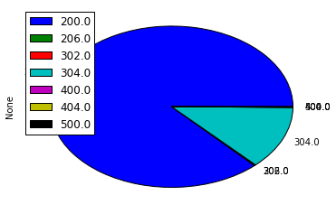

```python
%matplotlib inline
# show the percentage of each response code
import matplotlib.pyplot as plt
grouped.size().plot(kind='pie', legend=True)
```

#### Bar Chart

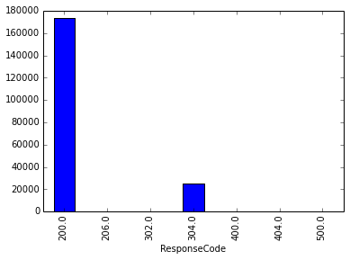

```python
# Or show as bar chart
grouped.size().plot(kind='bar')
```

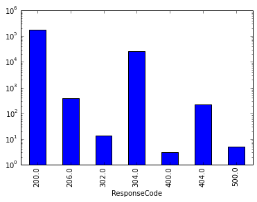

```python
# Since the diferences between the counts are huge, use logy y-axis
ax = grouped.size().plot(kind='bar')
ax.set_yscale('log', nonposy='clip')# the 'noposy='clip'' is to replace the invalid log(0) with a very small positive one
                                  # while doing the log-scale transition.
```

Now let's check how requests changes during different hour of the day on '01/May/1998'

#### Line Plot

```python
may1_df = log_df[log_df['Date'] == '01/May/1998']
may1_df.loc[:,('DateTime')] = pd.to_datetime(may1_df.apply(lambda row: row['Date'] + ' ' + row['Time'], axis=1))
hour_grouped = may1_df.groupby(lambda x: may1_df['DateTime'][x].hour)
```

```python
# Let's check how many requests were made during each hour of the day on '01/May/1998'
hour_grouped.size()
```

```
0      6569
1      6103
2      6072
3      6625
4      6019
5      4733
6      4995
7      5094
8      6460
9      7892
10     7465
11     7893
12    10127
13    10225
14    12040
15    12256
16    13367
17    11494
18    11515
19    10386
20     9363
21     6610
dtype: int64
```

```python
# and how much traffic the server handled during each hour:
hour_grouped['Size'].sum()
```

```
0     44166352.0
1     46857868.0
2     42803283.0
3     38868040.0
4     49190470.0
5     34184105.0
6     47877742.0
7     37838488.0
8     57224306.0
9     67645841.0
10    64193518.0
11    59961757.0
12    79150391.0
13    80907946.0
14    98825640.0
15    94044070.0
16    73413868.0
17    94389754.0
18    79264404.0
19    76209823.0
20    67784666.0
21    59834046.0
Name: Size, dtype: float64
```

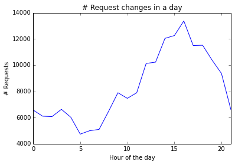

```python
# plot the changes of traffic on different hours of the day.
ax = hour_grouped.size().plot()
ax.set_ylabel("# Requests")
ax.set_xlabel("Hour of the day")
ax.set_title("# Request changes in a day")
```

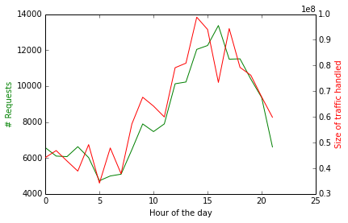

```python
# Let's show the # requests and size of traffic in a single graph:
fig, ax1 = plt.subplots()
ax2 = ax1.twinx()
x = hour_grouped.size().index

ax1.plot(x, hour_grouped.size(), 'g-')
ax2.plot(x, hour_grouped['Size'].sum(), 'r-')

ax1.set_xlabel('Hour of the day')
ax1.set_ylabel('# Requests', color='g')
ax2.set_ylabel('Size of traffic handled', color='r')
```

## Now it's your turn:

### Homework 2-2

NOTE: You don't have to submit this notebook for this homework, only answers of these questions are required to be submitted.

Questions:

1. Generate a line plot of the number of **distinct** users vs size of traffic of the site every hour on 01/May/1998, is there any correlation? (hint: use "hour_grouped['ClientID'].nunique()" to get the number of distinct users)
2. We wish to see if there is any correlation between client-ids and hours of the day at which they visit the website. Get 100 client ids from the dataset and generate a scatter plot that shows the hours of the day these clients sent requests. Hint: df.plot(kind='scatter', x='a', y='b'); and df['Column'].unique()
3. The log file used in the lab was from one day of the WorldCup. Lets apply our analysis to Jul/24 and Jul/25 in the log(wc_day91_1_log.csv). Repeat exercises 1 and 2 with it. How similar or different are the results?

# Question 1

```python
#Get data and group.

#Practice creating hour_grouped using lambda function.
#Grab all rows from original log with specific date.
q1_may1_df = log_df[log_df['Date'] == '01/May/1998']
#Construct datetime column.  Raster over all rows and add datetime.
#.apply will apply a function to all values in a pandas series.
#axis = 1 to apply "row-wise" https://stackoverflow.com/questions/22149584/what-does-axis-in-pandas-mean
q1_may1_df.loc[:,('DateTime')] = pd.to_datetime(q1_may1_df.apply(lambda row: row['Date'] + ' ' + row['Time'], axis = 1))
#group by the hour of the row
q1_hour_grouped = q1_may1_df.groupby(lambda x: q1_may1_df['DateTime'][x].hour)
```

```python
#Output groupig size to check with earlier in the lab.
q1_hour_grouped.size()
```

```
0      6569
1      6103
2      6072
3      6625
4      6019
5      4733
6      4995
7      5094
8      6460
9      7892
10     7465
11     7893
12    10127
13    10225
14    12040
15    12256
16    13367
17    11494
18    11515
19    10386
20     9363
21     6610
dtype: int64
```

```python
#Narrow down number of unique users and output lists.
uniqueUsers = q1_hour_grouped['ClientID'].nunique()
uniqueUsers
```

```
0      830
1      812
2      772
3      815
4      789
5      657
6      716
7      754
8      871
9      993
10     942
11     998
12    1165
13    1256
14    1416
15    1397
16    1501
17    1347
18    1308
19    1212
20    1161
21     925
Name: ClientID, dtype: int64
```

```python
#Calculate the size of the traffic on the site every hour.
q1_hour_grouped_traffic = q1_hour_grouped['Size'].sum()
q1_hour_grouped_traffic
```

```
0     44166352.0
1     46857868.0
2     42803283.0
3     38868040.0
4     49190470.0
5     34184105.0
6     47877742.0
7     37838488.0
8     57224306.0
9     67645841.0
10    64193518.0
11    59961757.0
12    79150391.0
13    80907946.0
14    98825640.0
15    94044070.0
16    73413868.0
17    94389754.0
18    79264404.0
19    76209823.0
20    67784666.0
21    59834046.0
Name: Size, dtype: float64
```

```
(0, 23)
```

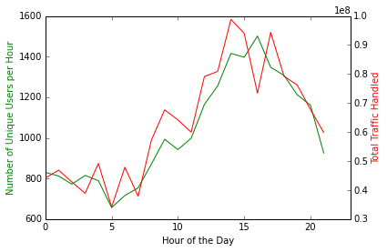

```python
#Generating double line plot with x-axis of hour, y1 axis of traffic, and y2 axis of unique users.
#use twinx to create another y-axis sharing the same x-axis.  subplots returns a figure object and a tuple.
fig, q1_axis1 = plt.subplots()
q1_axis2 = q1_axis1.twinx()
x = q1_hour_grouped.size().index

q1_axis1.plot(x, uniqueUsers, 'g-')
q1_axis2.plot(x, q1_hour_grouped_traffic, 'r-')

q1_axis1.set_xlabel('Hour of the Day')
q1_axis1.set_ylabel('Number of Unique Users per Hour', color='g')
q1_axis2.set_ylabel('Total Traffic Handled', color='r')

#Adjust x-axis to be from 0-23 hours (24 total hours in the day.)
q1_axis1.set_xlim(0,23)
```

There seems to be a correlations between number of unique users in the hour and the amount of traffic handled during that hour. As the number of unique users grows, so does the amount of traffic. As the number of unique users falls, so does the amount of traffic handled.

# Question 2

```python
#Interpreting the question as we need to see a correlation between a randomly selected set of 100
#users (client IDs) and the times at which they visited the website.  This will be accomplished with
#a scatter plot whose x-axis goes from 1-100 (randomly selected id indeces) and whose y-axis goes from
#0-23 for the hours of the day.  The most popular hours will be where the plotted points cluster in the
#y-axis direction.

#DISREGARD ABOVE ASSUMPTION.  After speaking with TA, the unique client ids should be found,
# then the first 100 unique client ids are selected, no need to randomize.  Instead of selecting
# only 1 row from the client id group, all rows from that client id group are added to the final
# scatter plot.

#Group data by client ID.  Will then later use to randomly select entry from client ID group.
q2_clientID_grouped = log_df.groupby('ClientID')
```

```python
#Get arry of distinct client id's from original log df.
#Select first 100 client ID's from the first 100 in the set.
q2_distinctClients = log_df['ClientID'].unique()
q2_distinctClients = q2_distinctClients[0:100]
import numpy as np
#q2_distinctClients = np.random.choice(q2_distinctClients, size=100)
#q2_distinctClients.size
```

```python
#Use client ID's to then find a client ID group
#then take all rows from that clientID group.
q2_selected_clients = pd.DataFrame()
for i in q2_distinctClients:
    q2_selected_clients = q2_selected_clients.append(q2_clientID_grouped.get_group(i))
```

```python
#Create indices from 1 to 100 for scatter plot.
#q2_selected_clients['GraphIndices'] = q2_selected_clients.reset_index().index + 1
#q2_selected_clients = q2_selected_clients[['hour','GraphIndices']]
```

```
(-1, 24)
```

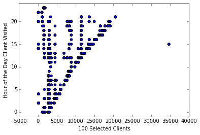

```python
#Create scatter plot comparing 100 unique clients and the hours they visited the site.
q2_plot = q2_selected_clients.plot(kind='scatter',x='ClientID',y='hour')
q2_plot.set_xlabel('100 Selected Clients')
q2_plot.set_ylabel('Hour of the Day Client Visited')
#q2_plot.set_xlim(0,101)
q2_plot.set_ylim(-1,24)
```

# Question 3

```python
#Load csv file and generate datetime column and URL_Type column
q3_log_df = pd.read_csv("./wc_day91_1_log.csv",
                     names=['ClientID', 'Date', 'Time', 'URL', 'ResponseCode', 'Size'],
                     na_values=['-'])
q3_log_df.loc[:,('DateTime')] = pd.to_datetime(q3_log_df.apply(lambda row: row['Date'] + ' ' + row['Time'], axis=1))
q3_log_df['hour'] = q3_log_df.DateTime.dt.hour
q3_log_df['URL_type'] = q3_log_df['URL'].str.split(".", n = -1, expand = False).str.get(-1)
```

```python
q3_log_df
```

|  | ClientID | Date | Time | URL | ResponseCode | Size | DateTime | hour | URL_type |
| --- | --- | --- | --- | --- | --- | --- | --- | --- | --- |
| 0 | 2743832 | 24/Jul/1998 | 22:00:01 | /english/history/body.html | 200 | 2909.0 | 1998-07-24 22:00:01 | 22 | html |
| 1 | 2572248 | 24/Jul/1998 | 22:00:01 | / | 200 | 4930.0 | 1998-07-24 22:00:01 | 22 | / |
| 2 | 31798 | 24/Jul/1998 | 22:00:02 | /french/competition/maincomp.htm | 200 | 12970.0 | 1998-07-24 22:00:02 | 22 | htm |
| 3 | 1848501 | 24/Jul/1998 | 22:00:02 | / | 200 | 4930.0 | 1998-07-24 22:00:02 | 22 | / |
| 4 | 248 | 24/Jul/1998 | 22:00:03 | /images/home_intro.anim.gif | 200 | 60349.0 | 1998-07-24 22:00:03 | 22 | gif |
| 5 | 2742956 | 24/Jul/1998 | 22:00:03 | /french/history/images/history_hm_nav.gif | 304 | 0.0 | 1998-07-24 22:00:03 | 22 | gif |
| 6 | 299067 | 24/Jul/1998 | 22:00:03 | /english/images/news_btn_part_off.gif | 304 | NaN | 1998-07-24 22:00:03 | 22 | gif |
| 7 | 2033693 | 24/Jul/1998 | 22:00:03 | /french/images/nav_venue_off.gif | 200 | 945.0 | 1998-07-24 22:00:03 | 22 | gif |
| 8 | 2560 | 24/Jul/1998 | 22:00:03 | /french/images/hm_top_stories_head.gif | 200 | 1170.0 | 1998-07-24 22:00:03 | 22 | gif |
| 9 | 65455 | 24/Jul/1998 | 22:00:03 | /images/hm_ligne1_col2.gif | 200 | 201.0 | 1998-07-24 22:00:03 | 22 | gif |
| 10 | 2033693 | 24/Jul/1998 | 22:00:03 | /french/images/nav_team_off.gif | 200 | 870.0 | 1998-07-24 22:00:03 | 22 | gif |
| 11 | 415336 | 24/Jul/1998 | 22:00:03 | /images/home_intro.anim.gif | 200 | 60349.0 | 1998-07-24 22:00:03 | 22 | gif |
| 12 | 65455 | 24/Jul/1998 | 22:00:03 | /images/hm_ligne1_col3.gif | 200 | 1065.0 | 1998-07-24 22:00:03 | 22 | gif |
| 13 | 2630107 | 24/Jul/1998 | 22:00:03 | /images/acc_welcome_f.gif | 200 | 2572.0 | 1998-07-24 22:00:03 | 22 | gif |
| 14 | 65455 | 24/Jul/1998 | 22:00:03 | /images/hm_ligne2_col1.gif | 200 | 322.0 | 1998-07-24 22:00:03 | 22 | gif |
| 15 | 2150066 | 24/Jul/1998 | 22:00:03 | /images/comp_bg2_hm.gif | 404 | 336.0 | 1998-07-24 22:00:03 | 22 | gif |
| 16 | 65455 | 24/Jul/1998 | 22:00:03 | /images/hm_hola.gif | 200 | 2240.0 | 1998-07-24 22:00:03 | 22 | gif |
| 17 | 2630107 | 24/Jul/1998 | 22:00:03 | /images/acc_anime.gif | 200 | 16456.0 | 1998-07-24 22:00:03 | 22 | gif |
| 18 | 2630107 | 24/Jul/1998 | 22:00:03 | /images/acc_welcome_e.gif | 200 | 2513.0 | 1998-07-24 22:00:03 | 22 | gif |
| 19 | 520440 | 24/Jul/1998 | 22:00:03 | /images/102383s.gif | 200 | 546.0 | 1998-07-24 22:00:03 | 22 | gif |
| 20 | 2743826 | 24/Jul/1998 | 22:00:04 | /english/individuals/playerphoto75952_1.htm | 200 | 5349.0 | 1998-07-24 22:00:04 | 22 | htm |
| 21 | 73721 | 24/Jul/1998 | 22:00:04 | /images/s102329.gif | 200 | 159.0 | 1998-07-24 22:00:04 | 22 | gif |
| 22 | 310517 | 24/Jul/1998 | 22:00:04 | /english/images/nav_field_off.gif | 200 | 1005.0 | 1998-07-24 22:00:04 | 22 | gif |
| 23 | 2743832 | 24/Jul/1998 | 22:00:04 | /english/history/images/history_hm_bg2.jpg | 200 | 22515.0 | 1998-07-24 22:00:04 | 22 | jpg |
| 24 | 2743832 | 24/Jul/1998 | 22:00:04 | /images/space.gif | 200 | 43.0 | 1998-07-24 22:00:04 | 22 | gif |
| 25 | 2743832 | 24/Jul/1998 | 22:00:04 | /english/history/images/history_hm_3094.gif | 200 | 1031.0 | 1998-07-24 22:00:04 | 22 | gif |
| 26 | 531 | 24/Jul/1998 | 22:00:04 | / | 200 | 4930.0 | 1998-07-24 22:00:04 | 22 | / |
| 27 | 494275 | 24/Jul/1998 | 22:00:04 | /images/mpa3806.jpg | 200 | 4000.0 | 1998-07-24 22:00:04 | 22 | jpg |
| 28 | 2033693 | 24/Jul/1998 | 22:00:04 | /french/Applet1.class | 200 | 4406.0 | 1998-07-24 22:00:04 | 22 | class |
| 29 | 2246522 | 24/Jul/1998 | 22:00:04 | /english/teams/teambio154.htm | 200 | 14814.0 | 1998-07-24 22:00:04 | 22 | htm |
| ... | ... | ... | ... | ... | ... | ... | ... | ... | ... |
| 1308326 | 35047 | 25/Jul/1998 | 21:59:52 | /english/images/fpnewstop.gif | 304 | 0.0 | 1998-07-25 21:59:52 | 21 | gif |
| 1308327 | 35047 | 25/Jul/1998 | 21:59:52 | /images/hm_f98_top.gif | 304 | 0.0 | 1998-07-25 21:59:52 | 21 | gif |
| 1308328 | 171477 | 25/Jul/1998 | 21:59:52 | /js/factoid.js | 304 | 0.0 | 1998-07-25 21:59:52 | 21 | js |
| 1308329 | 391731 | 25/Jul/1998 | 21:59:52 | /images/hm_btm_arw02.gif | 200 | 428.0 | 1998-07-25 21:59:52 | 21 | gif |
| 1308330 | 1801667 | 25/Jul/1998 | 21:59:52 | /images/hm_lbn_tp_rbtm.gif | 200 | 852.0 | 1998-07-25 21:59:52 | 21 | gif |
| 1308331 | 2746470 | 25/Jul/1998 | 21:59:52 | /english/playing/download/edbg1106.htm | 200 | 4941.0 | 1998-07-25 21:59:52 | 21 | htm |
| 1308332 | 250207 | 25/Jul/1998 | 21:59:52 | /french/individuals/playerphoto92699_1.htm | 200 | 5773.0 | 1998-07-25 21:59:52 | 21 | htm |
| 1308333 | 35047 | 25/Jul/1998 | 21:59:53 | /images/space.gif | 304 | 0.0 | 1998-07-25 21:59:53 | 21 | gif |
| 1308334 | 35047 | 25/Jul/1998 | 21:59:53 | /english/images/news_btn_comp_off.gif | 304 | 0.0 | 1998-07-25 21:59:53 | 21 | gif |
| 1308335 | 171477 | 25/Jul/1998 | 21:59:53 | /english/images/nav_tickets_off.gif | 304 | 0.0 | 1998-07-25 21:59:53 | 21 | gif |
| 1308336 | 171477 | 25/Jul/1998 | 21:59:53 | /english/images/store_anim_nav.gif | 304 | 0.0 | 1998-07-25 21:59:53 | 21 | gif |
| 1308337 | 1638204 | 25/Jul/1998 | 21:59:53 | /english/news/fig32603.htm | 200 | 38166.0 | 1998-07-25 21:59:53 | 21 | htm |
| 1308338 | 1910743 | 25/Jul/1998 | 21:59:54 | /images/acc_browsers.gif | 200 | 1682.0 | 1998-07-25 21:59:54 | 21 | gif |
| 1308339 | 1801667 | 25/Jul/1998 | 21:59:54 | /images/hm_btm_arw01.gif | 200 | 428.0 | 1998-07-25 21:59:54 | 21 | gif |
| 1308340 | 2746470 | 25/Jul/1998 | 21:59:54 | /images/14758.jpg | 200 | 2945.0 | 1998-07-25 21:59:54 | 21 | jpg |
| 1308341 | 171477 | 25/Jul/1998 | 21:59:54 | /english/images/nav_sitemap_off.gif | 304 | 0.0 | 1998-07-25 21:59:54 | 21 | gif |
| 1308342 | 171477 | 25/Jul/1998 | 21:59:54 | /english/images/nav_store_off.gif | 304 | 0.0 | 1998-07-25 21:59:54 | 21 | gif |
| 1308343 | 2746280 | 25/Jul/1998 | 21:59:54 | /english/news/recap38.htm | 200 | 14145.0 | 1998-07-25 21:59:54 | 21 | htm |
| 1308344 | 1801667 | 25/Jul/1998 | 21:59:54 | /english/images/hm_btm_prol.gif | 200 | 1306.0 | 1998-07-25 21:59:54 | 21 | gif |
| 1308345 | 2746470 | 25/Jul/1998 | 21:59:54 | /images/14760.jpg | 200 | 4461.0 | 1998-07-25 21:59:54 | 21 | jpg |
| 1308346 | 1801667 | 25/Jul/1998 | 21:59:54 | /images/hm_btm_arw02.gif | 200 | 428.0 | 1998-07-25 21:59:54 | 21 | gif |
| 1308347 | 171477 | 25/Jul/1998 | 21:59:55 | /english/images/nav_logo_sponsors.gif | 304 | 0.0 | 1998-07-25 21:59:55 | 21 | gif |
| 1308348 | 2746470 | 25/Jul/1998 | 21:59:55 | /images/14755.jpg | 200 | 2950.0 | 1998-07-25 21:59:55 | 21 | jpg |
| 1308349 | 1839921 | 25/Jul/1998 | 21:59:55 | /images/acc_tools.gif | 200 | 2696.0 | 1998-07-25 21:59:55 | 21 | gif |
| 1308350 | 1322287 | 25/Jul/1998 | 21:59:55 | /images/102320s.gif | 200 | 817.0 | 1998-07-25 21:59:55 | 21 | gif |
| 1308351 | 2746280 | 25/Jul/1998 | 21:59:55 | /english/teams/teamqualify125.htm | 200 | 14106.0 | 1998-07-25 21:59:55 | 21 | htm |
| 1308352 | 164486 | 25/Jul/1998 | 21:59:55 | /french/images/nav_team_off.gif | 200 | 870.0 | 1998-07-25 21:59:55 | 21 | gif |
| 1308353 | 2746465 | 25/Jul/1998 | 21:59:55 | /images/mpa6410.jpg | 304 | 0.0 | 1998-07-25 21:59:55 | 21 | jpg |
| 1308354 | 213256 | 25/Jul/1998 | 21:59:55 | /images/acc_tools.gif | 200 | 2696.0 | 1998-07-25 21:59:55 | 21 | gif |
| 1308355 | 2746470 | 25/Jul/1998 | 21:59:55 | /images/14756.jpg | 200 | 4235.0 | 1998-07-25 21:59:55 | 21 | jpg |

1308356 rows × 9 columns

```python
#Filter out rows just for July 24th, 1998
q3_jul24_log_df = q3_log_df[q3_log_df['Date'] == '24/Jul/1998']
```

```python
#Filter out rows just for July 25th, 1998
q3_jul25_log_df = q3_log_df[q3_log_df['Date'] == '25/Jul/1998']
```

QUESTION 1 REDONE WITH JULY 24TH DATA

```python
#Narrow down number of unique users and output lists.
q3_jul24_hour_grouped = q3_jul24_log_df.groupby(lambda x: q3_jul24_log_df['DateTime'][x].hour)
q3_jul24_uniqueUsers = q3_jul24_hour_grouped['ClientID'].nunique()
q3_jul24_uniqueUsers
```

```
22    1205
23    1166
Name: ClientID, dtype: int64
```

```python
#Calculate the size of the traffic on the site every hour.
q3_jul24_hour_grouped_traffic = q3_jul24_hour_grouped['Size'].sum()
q3_jul24_hour_grouped_traffic
```

```
22    308367954.0
23    273831997.0
Name: Size, dtype: float64
```

```
(22, 23)
```

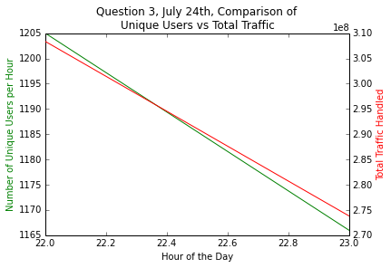

```python
#Generating double line plot with x-axis of hour, y1 axis of traffic, and y2 axis of unique users.
#use twinx to create another y-axis sharing the same x-axis.  subplots returns a figure object and a tuple.
%matplotlib inline
import matplotlib.pyplot as plt

fig, q3_jul24_axis1 = plt.subplots()
q3_jul24_axis2 = q3_jul24_axis1.twinx()
x = q3_jul24_hour_grouped.size().index

q3_jul24_axis1.plot(x, q3_jul24_uniqueUsers, 'g-')
q3_jul24_axis2.plot(x, q3_jul24_hour_grouped_traffic, 'r-')

q3_jul24_axis1.set_title('Question 3, July 24th, Comparison of \nUnique Users vs Total Traffic')
q3_jul24_axis1.set_xlabel('Hour of the Day')
q3_jul24_axis1.set_ylabel('Number of Unique Users per Hour', color='g')
q3_jul24_axis2.set_ylabel('Total Traffic Handled', color='r')

#Adjust x-axis to be from 0-23 hours (24 total hours in the day.)
q3_jul24_axis1.set_xlim(22,23)
```

There seems to be a correlations between number of unique users in the hour and the amount of traffic handled during that hour.

QUESTION 1 REDONE WITH JULY 25TH DATA

```python
#Narrow down number of unique users and output lists.
q3_jul25_hour_grouped = q3_jul25_log_df.groupby(lambda x: q3_jul25_log_df['DateTime'][x].hour)
q3_jul25_uniqueUsers = q3_jul25_hour_grouped['ClientID'].nunique()
q3_jul25_uniqueUsers
```

```
0     1083
1     1100
2     1152
3     1236
4     1163
5     1062
6     1007
7     1060
8     1027
9      950
10    1030
11     944
12    1076
13    1196
14    1246
15    1266
16    1274
17    1171
18    1097
19    1047
20    1032
21     919
Name: ClientID, dtype: int64
```

```python
#Calculate the size of the traffic on the site every hour.
q3_jul25_hour_grouped_traffic = q3_jul25_hour_grouped['Size'].sum()
q3_jul25_hour_grouped_traffic
```

```
0     254887315.0
1     299315349.0
2     333559527.0
3     335976803.0
4     253267003.0
5     232853603.0
6     239199885.0
7     227961601.0
8     292132496.0
9     288425535.0
10    268152384.0
11    254261855.0
12    251748043.0
13    289745702.0
14    307478577.0
15    319555678.0
16    381169538.0
17    347984361.0
18    307499565.0
19    287315331.0
20    277512322.0
21    224041283.0
Name: Size, dtype: float64
```

```
(0, 23)
```

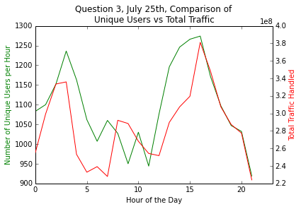

```python
#Generating double line plot with x-axis of hour, y1 axis of traffic, and y2 axis of unique users.
#use twinx to create another y-axis sharing the same x-axis.  subplots returns a figure object and a tuple.
%matplotlib inline
import matplotlib.pyplot as plt

fig, q3_jul25_axis1 = plt.subplots()
q3_jul25_axis2 = q3_jul25_axis1.twinx()
x = q3_jul25_hour_grouped.size().index

q3_jul25_axis1.plot(x, q3_jul25_uniqueUsers, 'g-')
q3_jul25_axis2.plot(x, q3_jul25_hour_grouped_traffic, 'r-')

q3_jul25_axis1.set_title('Question 3, July 25th, Comparison of \nUnique Users vs Total Traffic')
q3_jul25_axis1.set_xlabel('Hour of the Day')
q3_jul25_axis1.set_ylabel('Number of Unique Users per Hour', color='g')
q3_jul25_axis2.set_ylabel('Total Traffic Handled', color='r')

#Adjust x-axis to be from 0-23 hours (24 total hours in the day.)
q3_jul25_axis1.set_xlim(0,23)
```

There seems to be a correlations between number of unique users in the hour and the amount of traffic handled during that hour.

QUESTION 2 REDONE WITH JULY 24TH DATA

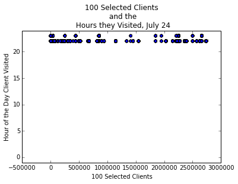

```python
#Group data by client ID.  Will then later use to select first entry from client ID group.
q3_jul24_clientID_grouped = q3_jul24_log_df.groupby('ClientID')
#Get arry of distinct client id's from original log df.
#Select first 100 client ID's from the first 100 in the unique set.
q3_jul24_distinctClients = q3_jul24_log_df['ClientID'].unique()
q3_jul24_distinctClients = q3_jul24_distinctClients[0:100]
#Use client ID's to then find a client ID group
#then take first row from that clientID group.
q3_jul24_selected_clients = pd.DataFrame()
for i in q3_jul24_distinctClients:
    q3_jul24_selected_clients = q3_jul24_selected_clients.append(q3_jul24_clientID_grouped.get_group(i))

#q3_jul24_selected_clients

#Create scatter plot comparing 100 unique clients and the hours they visited the site.
q3_jul24_plot = q3_jul24_selected_clients.plot(kind='scatter',x='ClientID',y='hour')
q3_jul24_plot.set_xlabel('100 Selected Clients')
q3_jul24_plot.set_ylabel('Hour of the Day Client Visited')
q3_jul24_plot.set_ylim(-1,24)
q3_jul24_plot.set_title('100 Selected Clients\n and the\n Hours they Visited, July 24')
```

QUESTION 2 REDONE WITH JULY 25TH DATA

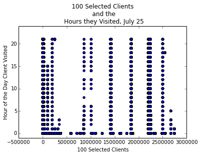

```python
#Group data by client ID.  Will then later use to select first entry from client ID group.
q3_jul25_clientID_grouped = q3_jul25_log_df.groupby('ClientID')
#Get arry of distinct client id's from original log df.
#Select first 100 client ID's from the first 100 in the unique set.
q3_jul25_distinctClients = q3_jul25_log_df['ClientID'].unique()
q3_jul25_distinctClients = q3_jul25_distinctClients[0:100]
#Use client ID's to then find a client ID group
#then take first row from that clientID group.
q3_jul25_selected_clients = pd.DataFrame()
for i in q3_jul25_distinctClients:
    q3_jul25_selected_clients = q3_jul25_selected_clients.append(q3_jul25_clientID_grouped.get_group(i))

#q3_jul24_selected_clients

#Create scatter plot comparing 100 unique clients and the hours they visited the site.
q3_jul25_plot = q3_jul25_selected_clients.plot(kind='scatter',x='ClientID',y='hour')
q3_jul25_plot.set_xlabel('100 Selected Clients')
q3_jul25_plot.set_ylabel('Hour of the Day Client Visited')
q3_jul25_plot.set_ylim(-1,24)
q3_jul25_plot.set_title('100 Selected Clients\n and the\n Hours they Visited, July 25')
```